## Binary Predicates and DE-9IM

Binary Predicates check topological relationships betweeen geometries. This can be very practical for data quality questions (e.g. “None of the State borders should ovelap”) or also for neighbourhood question (e.g. “which states border the state of Nevada?”).

Lets take the example of a chessboard:

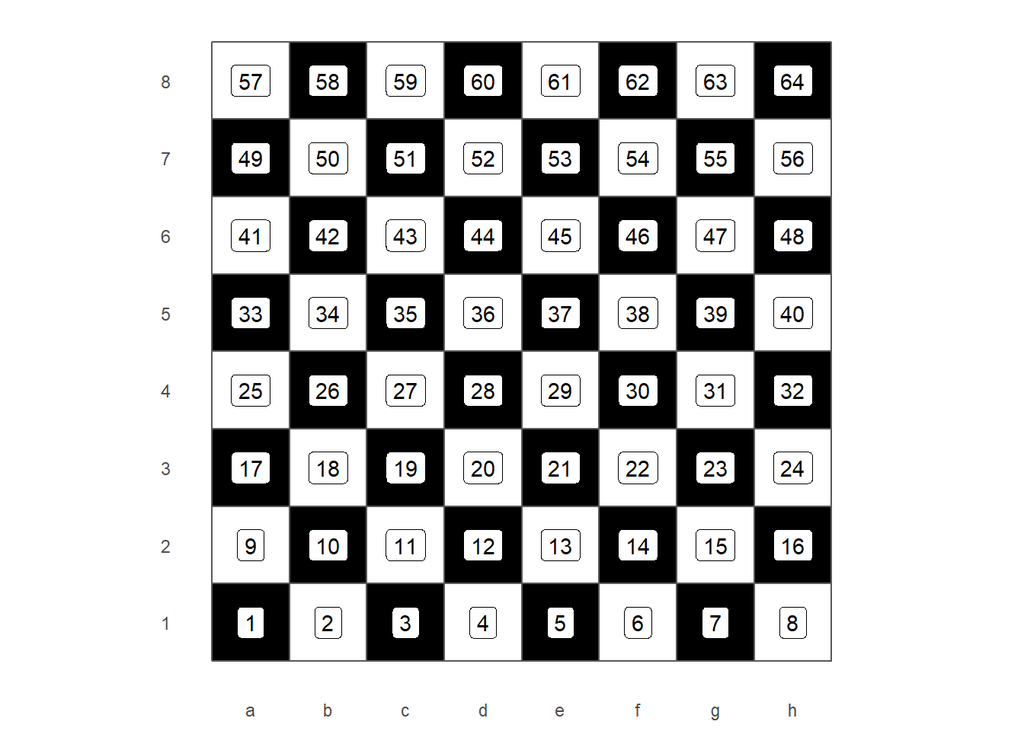

Some topological relationships have specific names. For example, if we want to know which field touch a specific field, the name for this predicate is “touches”. This is implemented in the function `st_touches` of the packages `sf`:

So to see which field touch field number 36, we can write the following line of code:

```r
st_touches(board[36,],board)
```

```
## Sparse geometry binary predicate list of length 1, where the predicate was `touches'
##  1: 27, 28, 29, 35, 37, 43, 44, 45
```

Visually, these are the following fields:

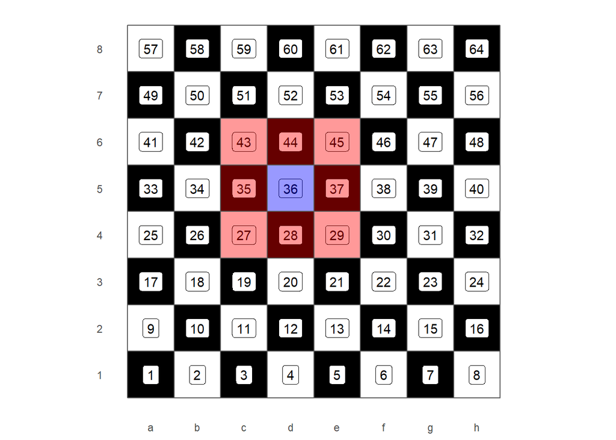

Similarly, there are further named topological relationships. Each of them has it’s own function in R:

- Contains (`st_contains`)
- Covers (`st_covers`)
- Intersects (`st_intersects`)
- Within / Inside (`st_within`)
- Covered by (`st_covered_by`)
- Crosses (`st_crosses`)
- Overlaps (`st_overlaps`)

Regarding the visual example above, we can imagine a chess piece placed on field #36. If this figure was a Queen or a King, all of the fields resulting from `st_touches` are reachable. In terms of contiguity, this is what is typically called the Queen’s or the King’s Case. However, this is might not the relationship that we are looking for: Say we would want to exclude the diagonal fields from our selection, the way a Rook would move in chess. How can we implement this in R?

None of the named topological relationships (binary predicates) above correctly describes this case (`touches_but_not_at_edges` or `shares_boundary` would be appropriate). In this case, we can use the Dimensionally Extended 9-Intersection Model (DE-9IM) to precisely formulate the realtionship we are looking for: the Rooks Case.

IN DE-9IM, the intersection of two objects is viewed at three levels for each object: The Interior, the Boundry and the Exterior ($3^2= 9$, hence the name). These levels mean different things for Polygons, Lines or Points, but let’s just look at the simple case for now, polygons (which is the case for our chess fields). Take the following example

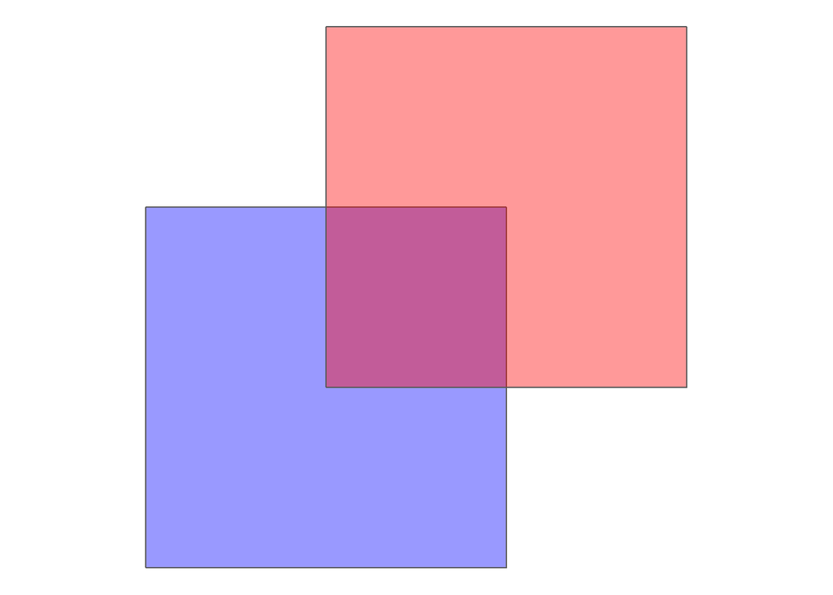

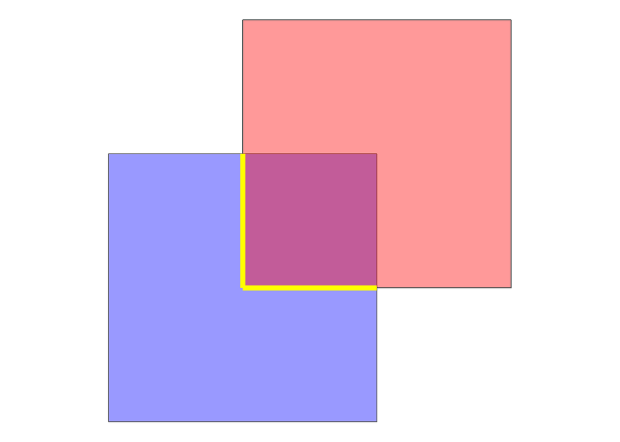

The resulting object has a dimenion “line”, i.e. 1. Formally: $dim(I(blue) \cap B(red)) = 1$. Now just for the sake of looking at the third level (Exerior), let’s look at what this looks like:

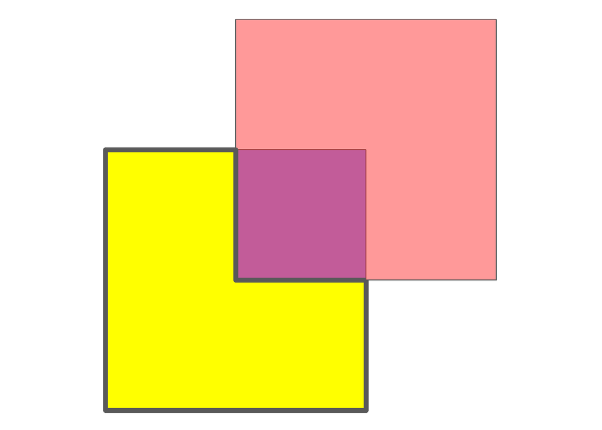

```r
p2_ls <- st_cast(p2,"LINESTRING")
p2_ls2 <- st_intersection(p1,p2_ls)

ggplot() +
  geom_sf(data = p1, fill = "blue", alpha = 0.4) +
  geom_sf(data = p2, fill = "red", alpha = 0.4)+
  geom_sf(data = st_difference(p1,p2), fill = "yellow", lwd = 2)+
  theme_void()
```

The resulting object is again an area, i.e. 2. Formally $dim(I(blue) \cap E(red)) = 2$.

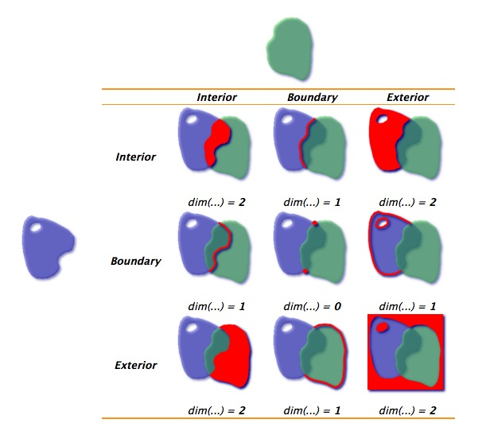

Why go through all this trouble? Because we would like to specify the rooks case, and none of the named predicates matches. So let’s define the rooks case ourselves:

## Rooks Case

If we go throught the all nine combinations of the DE-9IM, this is what defines the rooks case:

|  | Interior | Boundary | Exterior |
| --- | --- | --- | --- |
| Interior | **nothing** | dont care | dont care |
| Boundary | dont care | **Line** | dont care |
| Exterior | dont care | dont care | dont care |

Now that we have this string, we case use `st_relate()`and specify the string as the pattern we are looking for:

```r
st_relate(board[36,],board,pattern = "F***1****")
```

```
## Sparse geometry binary predicate list of length 1, where the predicate was `relate_pattern'
##  1: 28, 35, 37, 44
```

Which visually gives us this pattern:

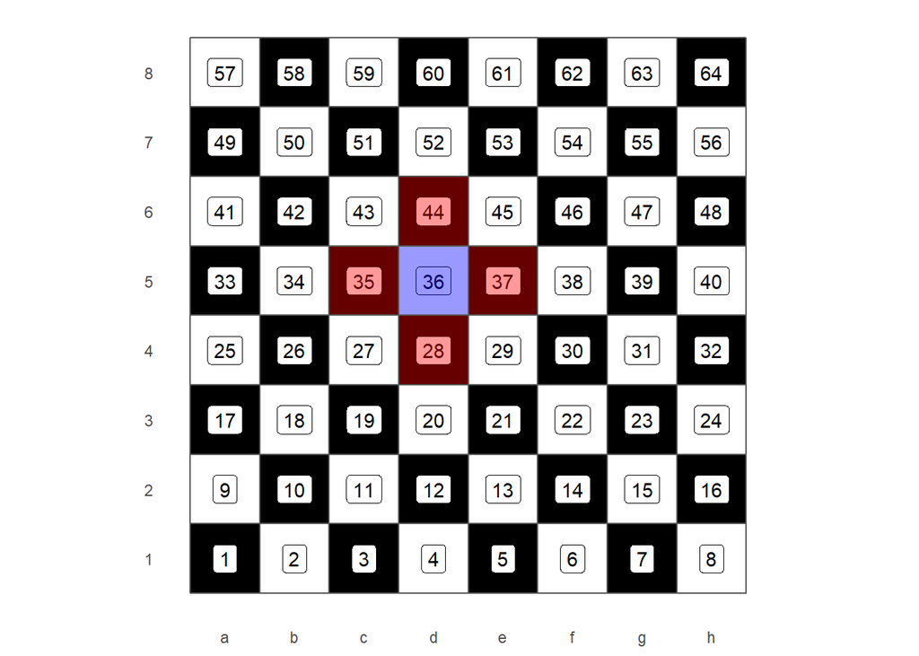

Because this was so much fun, let’s also have a look at the opposite, the Bishops Case.

## Bishops Case

|  | Interior | Boundary | Exterior |
| --- | --- | --- | --- |
| Interior | **nothing** | dont care | dont care |
| Boundary | dont care | **Point** | dont care |
| Exterior | dont care | dont care | dont care |

```r
st_relate(board[36,],board,pattern = "F***0****")
```

```
## Sparse geometry binary predicate list of length 1, where the predicate was `relate_pattern'
##  1: 27, 29, 43, 45
```

Visually:

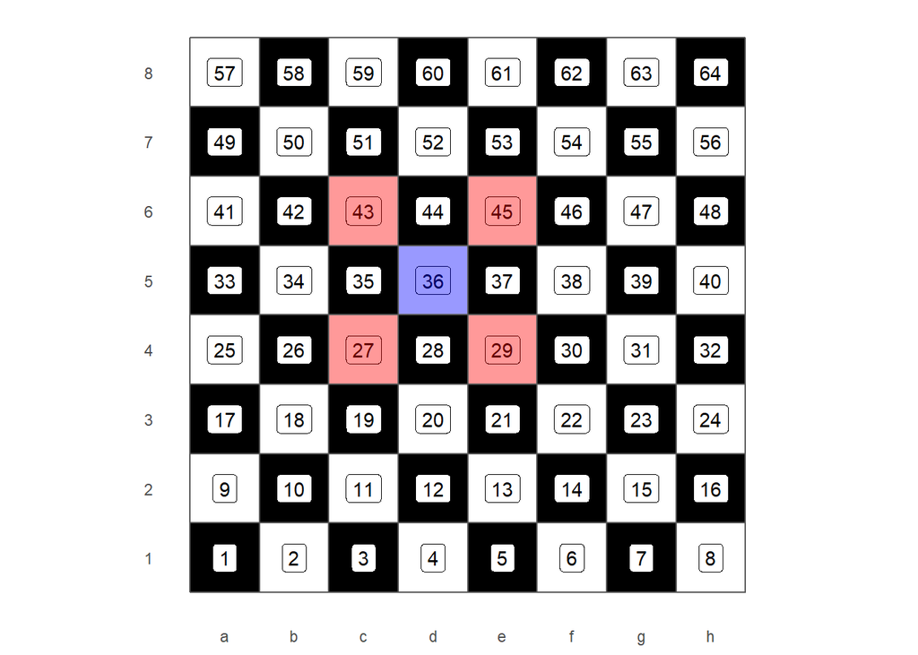

## Toplogy Rules

in ArcGIS, you create a topology rule by first creating a Feature Dataset in a Geodatabase, and then adding one or more Topology Rules to that Feature Dataset. In R, you can check topology using the DE-9IM together with `st_relate()`.

### Must not overlap

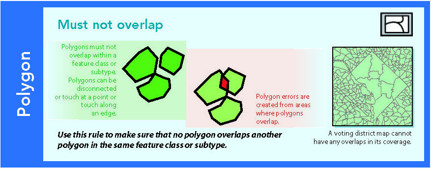

In context of DE-9IM, this is a simple case. The polygon interiors should not overlap *at all*, everything else does not matter. Interior-Interior is the first of the 9 intersections, so the the intersection matrix as a code string would be: **2**********. In the case of the example below:

```r
set.seed(10)
nrows <- 10
circs <- data.frame(
  id = 1:nrows,
  x = rnorm(nrows),
  y = rnorm(nrows)
) %>%
  st_as_sf(coords = c(2,3)) %>%
  st_buffer(0.25)
```

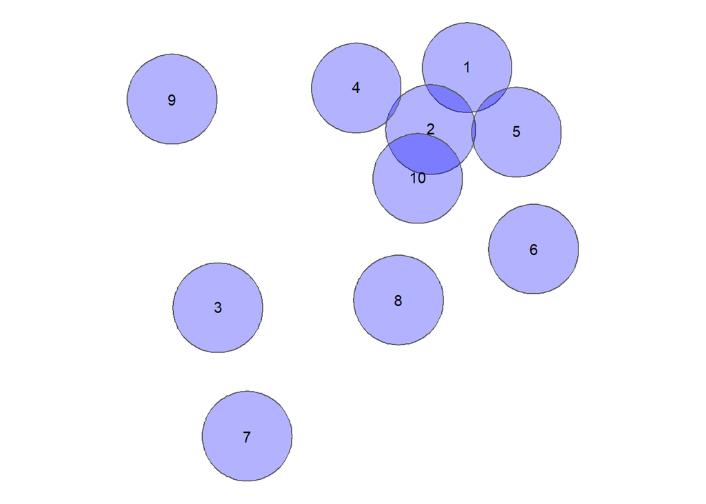

```r
circsplot <- ggplot(circs) +
  geom_sf(fill = "blue",alpha = 0.3) +
  geom_sf_text(aes(label = id)) +
  theme_void()
circsplot
```

This gives us a sparse matrix as an output, which is esentially a list with the same length as the `x`, where each position is a vector of integers with the indicies of the features in `y` (which may equal to `x`) where the pattern matches.

```r
st_relate(circs,pattern = "2********")
```

```
## Sparse geometry binary predicate list of length 10, where the predicate was `relate_pattern'
##  1: 1, 2, 5
##  2: 1, 2, 4, 5, 10
##  3: 3
##  4: 2, 4
##  5: 1, 2, 5
##  6: 6
##  7: 7
##  8: 8
##  9: 9
##  10: 2, 10
```

Setting `sparse = FALSE` returns a crossmatrix of all combinations.W

```r
crossmatrix <- st_relate(circs,pattern = "2********",sparse = FALSE)
crossmatrix[1:6,1:6] # only showing 6 since this prints nicely
```

```
##       [,1]  [,2]  [,3]  [,4]  [,5]  [,6]
## [1,]  TRUE  TRUE FALSE FALSE  TRUE FALSE
## [2,]  TRUE  TRUE FALSE  TRUE  TRUE FALSE
## [3,] FALSE FALSE  TRUE FALSE FALSE FALSE
## [4,] FALSE  TRUE FALSE  TRUE FALSE FALSE
## [5,]  TRUE  TRUE FALSE FALSE  TRUE FALSE
## [6,] FALSE FALSE FALSE FALSE FALSE  TRUE
```

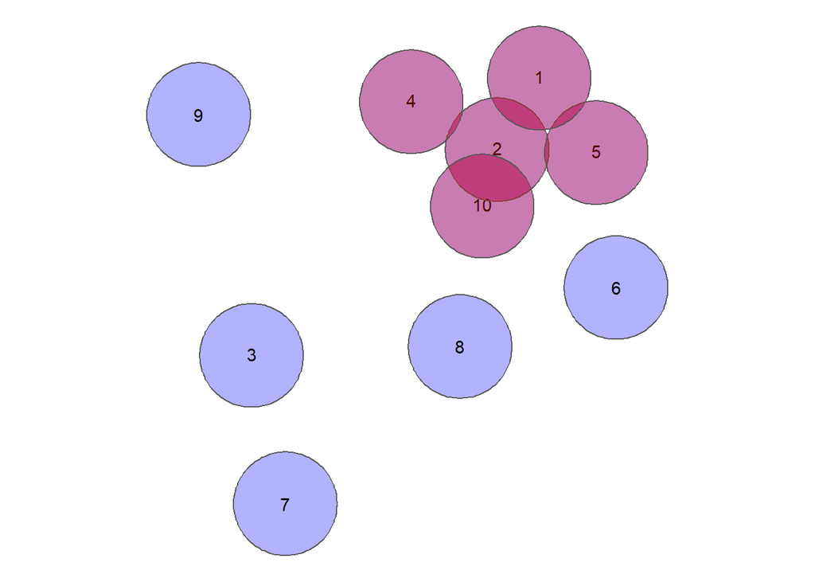

```r
# Remove the diagonals since it's simply each feature tested against itself
diag(crossmatrix) <- FALSE
error <- which(crossmatrix,arr.ind = TRUE) %>%
  as.vector() %>%
  unique()


circsplot +
  geom_sf(data = circs[error,], fill = "red", alpha = 0.3)
```

### Must not have gaps

[figure not shown]

```r
nc = st_read(system.file("shape/nc.shp", package="sf"), quiet = TRUE)

st_union(nc)
```

```
## Geometry set for 1 feature
## geometry type:  MULTIPOLYGON
## dimension:      XY
## bbox:           xmin: -84.32385 ymin: 33.88199 xmax: -75.45698 ymax: 36.58965
## epsg (SRID):    4267
## proj4string:    +proj=longlat +datum=NAD27 +no_defs
```